# Module 3: overview of selected data analysis methods for high-dimensional data

# Principal Component Analysis

**Principal Component Analysis** (**PCA**) is a *linear* *unsupervised* method of *dimension reduction*.

This means that:

- PCA is based on application of linear transformations,
- it takes into account data parameters only, ignoring a priori the labels, if exist,
- it allows to reduce the number of data features to a smaller one (the new features are *linear combinations* of the old ones).

Let $X_1,\ldots,X_p$ be the set of feature variables. Given that data, PCA finds a new set of variables $Y_1,\ldots,Y_p$ such that:

- each $Y_i$ is a *linear combination* of the features, that is $Y_i=\phi_{i,1}X_1+\ldots +\phi_{i,p}X_p$,
- $Y_1$ has the maximum variance among all such linear combinations,
- $Y_2$ is uncorrelated to $Y_1$ and has the maximum variance,
- in general: $Y_i$ is uncorrelated to $Y_1,\ldots,Y_{i-1}$ and has the maximal variance.

The coefficients $\phi_{i,j}$ are called *loadings* of the $i$-th principal component (that is $Y_{i}$).

In practice, though, we are not given random variables $X_i$ but rather the data representing it. In that way, each of $X_i$ is a finite column vector, say of length $m$, and the whole data can be arranged into a matrix $$ X=\left([X_{i,j}]_{1\leq i\leq p, 1\leq j\leq m}\right)^T. $$

## Comments concerning PCA

- in principle, it is an *unsupervised* learning method, i.e. we only care about the features, not the labels (one can apply it though in the supervised case as well - we discuss it later)
- PCA is sensitive to scaling in the data (by desing)
- We need to standarize the input: center and scale the data
- PCA creates a new basis, which is orthogonal by design:

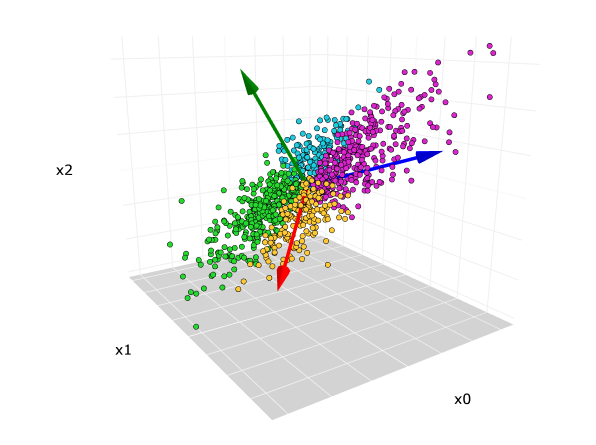

source: https://towardsdatascience.com/principal-component-analysis-pca-explained-visually-with-zero-math-1cbf392b9e7d

- To get loadings $\phi$'s and components' variances $\lambda$'s we can:
  - Perform eigenvalue decomposition of $X^TX$

  or
  - Perform SVD decomposition of $X$: $$ X=U\Sigma V^T, $$ where $U$ is a $n\times n$ matrix called the *score matrix* and $V$ is a $p\times p$ matrix called the *loading matrix*
- The cutoff parameter can be decided using cross validation.
- PCA can be a preprocessing step for other methods, e.g. linear regression
  - "Good representation is all you need"

## Example: Iris dataset

```python
from sklearn import datasets

iris = datasets.load_iris()
X = iris.data
y = iris.target
```

```python
X
```

```python
y
```

### Scale the data

```python
# In general, it's a good idea to scale the data prior to PCA.

from sklearn.preprocessing import StandardScaler

scaler = StandardScaler()
scaler.fit(X)
X = scaler.transform(X)

X
```

### Perform PCA

```python
from sklearn.decomposition import PCA

pca = PCA()
x_new = pca.fit_transform(X)

x_new
```

### Loadings of PCA

```python
import numpy as np
import pandas as pd

# loadings = columns of the following dataframe
# vectors ploted on a biplot - rows of this dataframe
loadings = pca.components_.T * np.sqrt(pca.explained_variance_)

loading_matrix = pd.DataFrame(loadings[:,:2], columns=['PC1', 'PC2'], index=iris.feature_names)

loading_matrix
```

```python
pca.components_
```

```python
np.transpose(pca.components_[1:3, :])
```

### Biplots

```python
import matplotlib.pyplot as plt

def biplot(score,coeff,labels=None):
    xs = score[:,0]
    ys = score[:,1]
    n = coeff.shape[0]
    scalex = 1.0/(xs.max() - xs.min())
    scaley = 1.0/(ys.max() - ys.min())
    plt.scatter(xs * scalex,ys * scaley, c = y)
    for i in range(n):
        plt.arrow(0, 0, coeff[i,0], coeff[i,1],color = 'r',alpha = 0.5)
        if labels is None:
            plt.text(coeff[i,0]* 1.15, coeff[i,1] * 1.15, "Var"+str(i+1), color = 'g', ha = 'center', va = 'center')
        else:
            plt.text(coeff[i,0]* 1.15, coeff[i,1] * 1.15, labels[i], color = 'g', ha = 'center', va = 'center')
    plt.xlim(-1,1)
    plt.ylim(-1,1)
    plt.xlabel("first considered component")
    plt.ylabel("second considered component")
    plt.grid()

# code source: https://stackoverflow.com/questions/39216897/plot-pca-loadings-and-loading-in-biplot-in-sklearn-like-rs-autoplot
```

```python
biplot(x_new[:,0:2],np.transpose(pca.components_[0:2, :]))
```

```python
biplot(x_new[:,1:3],np.transpose(pca.components_[1:3, :]))
```

### Proportion variance explained

```python
pca.explained_variance_
```

```python
pca.explained_variance_ratio_
```

```python
import seaborn as sns # install via "pip install seaborn" in terminal if the command is not working
```

```python
pve_df = pd.DataFrame({'component': [1,2,3,4], 'PVE': pca.explained_variance_ratio_})

cumulative_pve = [0]*(len(pca.explained_variance_ratio_)+1)
cumulative_pve[0] = 0
cumulative_pve[1] = pca.explained_variance_ratio_[0]
for i in range(1,len(pca.explained_variance_ratio_)+1):
    cumulative_pve[i] = cumulative_pve[i-1]+pca.explained_variance_ratio_[i-1]

cumulative_pve_df = pd.DataFrame({'component': [0,1,2,3,4], 'cumulative PVE': cumulative_pve})

fig, axs = plt.subplots(ncols=2)

sns.pointplot(x='component', y='PVE', data=pve_df, ax=axs[0]);
sns.pointplot(x='component', y='cumulative PVE', data=cumulative_pve_df, ax=axs[1]);
```

## Principal Component Regression (PCR) - PCA as a prestep for supervised learning - diabetes dataset

### Load the dataset

```python
# Provide scikit
import sklearn
from sklearn import datasets
```

```python
diabetes = datasets.load_diabetes()
```

```python
diabetes.feature_names
```

```python
diabetes.data
```

```python
diabetes.target
```

```python
X, y = diabetes.data, diabetes.target
```

```python
X
```

### Perform PCA

```python
# In general, it's a good idea to scale the data prior to PCA.
from sklearn.preprocessing import StandardScaler
```

```python
scaler = StandardScaler()
scaler.fit(X)
X = scaler.transform(X)
```

```python
X
```

```python
from sklearn.decomposition import PCA
```

```python
pca = PCA()
X_pca = pca.fit_transform(X)
```

```python
X_pca
```

```python
pca.explained_variance_ratio_
```

```python
import seaborn as sns
import pandas as pd
import matplotlib.pyplot as plt
```

```python
pve_df = pd.DataFrame({'component': [1,2,3,4,5,6,7,8,9,10], 'PVE': pca.explained_variance_ratio_})

cumulative_pve = [0]*(len(pca.explained_variance_ratio_)+1)
cumulative_pve[0] = 0
cumulative_pve[1] = pca.explained_variance_ratio_[0]
for i in range(1,len(pca.explained_variance_ratio_)+1):
    cumulative_pve[i] = cumulative_pve[i-1]+pca.explained_variance_ratio_[i-1]

cumulative_pve_df = pd.DataFrame({'component': [0,1,2,3,4,5,6,7,8,9,10], 'cumulative PVE': cumulative_pve})

fig, axs = plt.subplots(ncols=2)

sns.pointplot(x='component', y='PVE', data=pve_df, ax=axs[0]);
sns.pointplot(x='component', y='cumulative PVE', data=cumulative_pve_df, ax=axs[1]);
```

### Select the principal components with highest variance

```python
X_pca_selected = X_pca[:,[0,1]]
```

```python
X_pca_selected
```

### Split the data into train and test (we want to compare the results)

```python
# We import the submodule allowing to split the data into train and test parts
from sklearn.model_selection import train_test_split
```

```python
data_idies = range(len(X))
```

```python
data_idies
```

```python
idies_train, idies_test = train_test_split(data_idies, test_size=0.35)
```

```python
y_train, y_test = y[idies_train], y[idies_test]
```

```python
X_train, X_test = X[idies_train], X[idies_test]
```

```python
X_pca_train, X_pca_test = X_pca_selected[idies_train], X_pca_selected[idies_test]
```

### Create regression models

```python
# we must load the linear regression submodule
from sklearn.linear_model import LinearRegression
```

```python
def regression_model(x, y):
    model = LinearRegression()
    model.fit(x, y)
    return model
```

```python
original_model = regression_model(X_train, y_train)
```

```python
pca_model = regression_model(X_pca_train, y_train)
```

### Assess the accuracy of the models

#### Residual sum of squares and its estimator:

$$ RSS = \sum_{i=1}^n(y_i-(y\_{\text{predict})_i})^2,\\ RSE=\sqrt{\frac{1}{n-2}RSS}, $$ where $n$ is the number of test samples taken for the assessment.

#### $R^2$ - the "normalized" RSS

$$ TSS = \sum_i (y_i - \bar{y})^2 $$

$$ R^2 = \frac{TSS- RSS}{TSS}$$

```python
import numpy as np
```

```python
def RSS_RSE(model, x, y):
    y_predict = model.predict(x)
    n = len(x)
    RSS = sum((y-y_predict)**2)
    RSE = np.sqrt(1/(n-2)*RSS)
    return RSS, RSE
```

```python
def R2(model, x, y):
    y_mean = np.mean(y)
    TSS = sum((y-y_mean)**2)
    RSS, RSE = RSS_RSE(model, x, y)
    return (TSS-RSS)/TSS
```

```python
rss_rse_original_train = R2(original_model, X_train, y_train)
rss_rse_original_test = R2(original_model, X_test, y_test)
rss_rse_pca_train = R2(pca_model, X_pca_train, y_train)
rss_rse_pca_test = R2(pca_model, X_pca_test, y_test)
```

```python
print("r2_original_train:", rss_rse_original_train)
print("r2_original_test:", rss_rse_original_test)
print("r2_pca_train:", rss_rse_pca_train)
print("r2_pca_test:", rss_rse_pca_test)
```

```python
def R2_k_components(k):
    X_pca_selected = X_pca[:,[i for i in range(k)]]
    X_pca_train, X_pca_test = X_pca_selected[idies_train], X_pca_selected[idies_test]
    pca_model = regression_model(X_pca_train, y_train)
    r2_train = R2(pca_model, X_pca_train, y_train)
    r2_test = R2(pca_model, X_pca_test, y_test)
    return r2_train, r2_test
```

```python
r2_train_pca, r2_test_pca = [0]*10, [0]*10
for k in range(1,10):
    r2_train_pca[k], r2_test_pca[k] = R2_k_components(k)
```

```python
r2_train_pca
```

```python
r2_test_pca
```

```python
train_df = pd.DataFrame({'component': [1,2,3,4,5,6,7,8,9,10], 'pca train': r2_train_pca})
test_df = pd.DataFrame({'component': [1,2,3,4,5,6,7,8,9,10], 'pca test': r2_test_pca})

fig, axs = plt.subplots(ncols=2)

sns.pointplot(x='component', y='pca train', data=train_df, ax=axs[0]);
sns.pointplot(x='component', y='pca test', data=test_df, ax=axs[1]);
```

# Feature selection

## Best subset selection (brute force)

1. Let $\mathcal M_0$ denote the null model, which contains no predictors. This model simply predicts the sample mean for each observation.
2. For $k=1,\ldots,p$:

(a) Fit all $p_k$ models that contain exactly k predictors.

(b) Pick the best among these $p_k$ models, and call it $\mathcal M_k$. Here best is defined as having the smallest RSS, or equivalently largest $R^2$.

3. Select a single best model from among $\mathcal M_0, \ldots, \mathcal{M}_p$ using cross-validated prediction error, Mallow’s $C_{p}$, Akaike information critetion (AIC), Bayesian information criterion (BIC), or adjusted $R^2$

## Stepwise selection

- Exhastive search requires to checks all $2^p$ model
- Best subset selection may also suffer from statistical problems when p is large: larger the search space, the higher the chance of finding models that look good on the training data, even though they might not have any predictive power on future data.
- Thus an enormous search space can lead to overfitting and high variance of the coefficient estimates.
- For both of these reasons, stepwise methods, which explore a far more restricted set of models, are attractive alternatives to best subset selection.

### Forward Stepwise Selection (Greedy)

1. Let $\mathcal M_0$ denote the null model, which contains no predictors.
2. For $k = 0, \ldots, p-1$:

(a) Consider all $p − k$ models that augment the predictors in $\mathcal M_k$ with one additional predictor.

(b) Choose the best among these p − k models, and call it $\mathcal M_{k+1}$. Here best is defined as having smallest RSS or highest R2.

3. Select a single best model from among $\mathcal M_0, \ldots, \mathcal{M}_p$ using cross-validated prediction error, Cp (AIC), BIC, or adjusted $R^2$
- Computational advantage over best subset selection is clear.
- It is not guaranteed to find the best possible model out of all $2^p$ models containing subsets of the p predictors.
- Forward selection works in the case $n<p$. Then you perform the iteration up to $n-1$.

### Backward Stepwise Selection (Greedy)

1. Let $\mathcal M_p$ denote the full model, which contains all $p$ predictors.
2. For $k=p,p-1,\ldots, 1$:

(a) Consider all $k$ models that contain all but one of the predictors in $\mathcal M_k$, for a total of $k − 1$ predictors.

(b) Choose the best among these k models, and call it $\mathcal M_{k−1}$. Here best is defined as having smallest RSS or highest R2.

3. Select a single best model from among $\mathcal M_0, \ldots, \mathcal{M}_p$ using cross-validated prediction error, Cp (AIC), BIC, or adjusted $R^2$.
- Like forward stepwise selection, the backward selection approach searches through only $1 + p(p + 1)/2$ models, and so can be applied in settings where p is too large to apply best subset selection
- Like forward stepwise selection, backward stepwise selection is not guaranteed to yield the best model containing a subset of the p predictors.
- Backward selection requires that the number of samples n is larger than the number of variables p (so that the full model can be fit). In contrast, forward stepwise can be used even when n < p, and so is the only viable subset method when p is very large.

## Choosing the Optimal Model

We would like to select the best model with respect to the test error. The two common approaches are:

- indirect estimatation of the test error by making an adjustment to the training error to account for the bias due to overﬁtting,
- direct estimation of the test error, using either validation cross-validation

### Information Criteria

- Below $d$ is the total # of parameters used and $\hat{\sigma}^2$ is an estimate of the variance of the error ($\hat{\sigma}^2$ is an estimate for $\epsilon$, where the regression relationship is given by $ Y = f(X_1, \ldots, X_p) + \epsilon $ - typically $\hat{\sigma}^2$ is estimated using the full model containing all predictors).
- All the criteria add a penalty for the size of the model.
  - we know that increasing the number of parametres decreases RSS
  - the penalty acts in the oposite direction
- Mallow’s Cp:

$$ C_p = \frac{1}{n} (RSS + 2d\hat{\sigma}^2 ) $$

- Akaike Criterion:

$$ AIC = \frac{1}{n\hat{\sigma}^2} (RSS + 2d\hat{\sigma}^2 ) $$

- Bayes Criterion:

$$ BIC = \frac{1}{n}(RSS + log(n)d\hat{\sigma}^2 ) $$

- $R^2$

$$ R^2 = 1 - \frac{RSS}{TSS} $$

- Adjusted $R^2$

$$ \text{Adjusted } R^2 = 1 − \frac{RSS/(n − d-1)}{TSS/(n − 1)} $$

#### Example: credit data

```python
# Run it if not yet downloaded only

import urllib.request
import zipfile
import os
from pathlib import Path

url = "https://www.statlearning.com/s/ALL-CSV-FILES-2nd-Edition-corrected.zip"
zip_path = Path("ALL-CSV-FILES-2nd-Edition-corrected.zip")
extract_dir = Path("ALL-CSV-FILES-2nd-Edition-corrected")

# 1) download only if not present
if not zip_path.exists():
    print("Downloading zip...")
    urllib.request.urlretrieve(url, zip_path)
    print("Saved to", zip_path)
else:
    print("Zip already exists:", zip_path)

# 2) unzip
if not extract_dir.exists():
    print("Extracting...")
    with zipfile.ZipFile(zip_path, "r") as zf:
        zf.extractall(extract_dir)
    print("Extracted to", extract_dir)
else:
    print("Already extracted to:", extract_dir)

# 3) list extracted files
print("\nFiles:")
for p in sorted(extract_dir.glob("**/*")):
    if p.is_file():
        print(p)
```

```python
import pandas as pd
```

```python
credit_df = pd.read_csv('ALL-CSV-FILES-2nd-Edition-corrected/ALL CSV FILES - 2nd Edition/Credit.csv')
```

```python
credit_df
```

```python
import statsmodels.formula.api as smf # install via "pip install statsmodels" in terminal if the command is not working
import numpy as np
from itertools import combinations
```

```python
# region is categorical with 3 possible values
# so the number of predictors is (10-1) + 2 = 11
n_predictors_with_dummy = 11
n = len(credit_df)
cp, bic, adj_r2 = [], [], []

# estimate σ^2
columns = credit_df.columns[:-1]
formula = f'{credit_df.columns[-1]} ~ {" + ".join(columns)}'
object_to_fit = smf.ols(formula, credit_df)
model = object_to_fit.fit()
sigma2 = np.sum(model.resid**2)/(n-len(columns)-1)

# Best subset selection (brute force)
# Step 2.
for d in range(1, n_predictors_with_dummy):
    r2_max = 0
    for selection in combinations(range(len(columns)), d):
        selection = list(selection)
        formula = f'{credit_df.columns[-1]} ~ {" + ".join(columns[selection])}'
        p_k = smf.ols(formula, credit_df).fit()
        rss = p_k.ssr
        tss = p_k.centered_tss
        if 1-rss/tss > r2_max:
            r2_max = 1-rss/tss
            M_k = p_k

    rss = M_k.ssr
    tss = M_k.centered_tss
    cp.append(1/n * (rss + 2 * d * sigma2))
    bic.append(1/n * (rss + np.log(n) * d * sigma2))
    adj_r2.append(1 - rss / (n - d - 1) * (n - 1) / tss)
```

```python
import seaborn as sns
```

```python
plot_df = pd.concat([
  pd.DataFrame({'val': cp, 'type': 'cp'}).reset_index(),
  pd.DataFrame({'val': bic, 'type': 'bic'}).reset_index(),
])
plot_df['index'] += 1
plot_df = plot_df.reset_index(drop=True)
sns.pointplot(x='index', y='val', hue='type', data=plot_df);
```

```python
bic
```

```python
r2_df = pd.DataFrame({'val': adj_r2, 'type': 'adj_r2'}).reset_index()
sns.pointplot(x='index', y='val', data=r2_df);
```

```python
adj_r2
```

# Shrinkage

- Ridge regression and Lasso
- The subset selection methods use least squares to fit a linear model that contains a subset of the predictors.
- As an alternative, we can fit a model containing all $p$ predictors using a technique that regularizes (shrinks) the coefficient estimates
- It may not be immediately obvious why such a constraint should improve the fit, but they do
- Different kinds of regularizations are very common in the modern Machine Learning and substantially improve training for big models
- It might happen that tuning the key hyperparameters is painful

## Ridge regression

- The new, regularized loss function of ridge regression is of the following form:

$$ RSS + \lambda ||\beta||_2^2 = RSS + \lambda\sum_{j=1}^p\beta_j^2 $$

- $\lambda$ is a hyperparameter than needs to be tuned
- Ridge regression cares about balancing between two objectives:
  - Mninimiaze RSS, at the least suqares
  - Keepnig the magnitude of parameters small (close to zero)
  - The tuning parameter $\lambda$ controls the relative impact of these two losses
- Selecting a good value for $\lambda$ is critical (there are people in the industry that specialize in this kind of work)
- Here we will use cross-validation. Often you just use some kind of grid search.
- We do not want to shrink the intercept, as it corresponds to the mean of the data (when x's are 0)

## Lasso

- The new, regularized loss funtion of lasso regression is of the following form:

$$ RSS + \lambda ||\beta||_1 = RSS + \lambda\sum_{j=1}^p|\beta_j| $$

## Ridge vs lasso

- Neither ridge regression nor the lasso will universally dominate the other.
- Lasso performs better in sparse case (small number of nonzero coeffs).
- Ridge does well if there is a lot of predictors correlated with the outcome.
- The number of predictors that is related to the response is never known a priori for real data sets.

# Programming tasks

## Task 1: Assess accuracy of regression models distilled by PCA

**Input:**

- a plot presenting $R^2$ for the model defined by the first $k$ principal components. The $X$ axis correspond to $k$, and the $Y$ axis to $R^2$.

# Sources used for preparation of this notebook

- a substantial part of this notebook constitutes the notes of dr Łukasz Kuciński, https://sites.google.com/view/lukaszkucinski, from Institute of Mathematics of the Polish Academy of Sciences; his notes were from the course on modern methods of data analysis
- G. James, D. Witten, T. Hastie, R. Tibshirani, J. Taylor, [*An Introduction to Statistical Learning with Applications in Python (ISLP)*, 2023](https://hastie.su.domains/ISLP/ISLP_website.pdf.download.html) and its associated slides - some of the descriptions here were taken from these [slides](https://www.statlearning.com/resources-python), e.g. [chatper 6 slides](https://hastie.su.domains/ISLR2/Slides/Ch6_Model_Selection.pdf)